# Language in the legal process

From the police caution to the courtroom

Dr Massimiliano Canzi

# Thirty-seven words

`Did you know:` vervet monkeys give different alarm calls for leopards, eagles and snakes. When researchers played the recorded calls with no predator around, the monkeys ran into trees at leopard alarms, looked up at eagle alarms and looked down at snake alarms.

*Source: Seyfarth, Cheney & Marler (1980), Science*

## The caution

Since the mid-1990s, suspects in England and Wales have heard the police caution in these words (PACE Code C, 10.5):

> You do not have to say anything. But it may harm your defence if you do not mention when questioned something which you later rely on in court. Anything you do say may be given in evidence.

The second of its three sentences reflects the Criminal Justice and Public Order Act 1994, which lets a court draw conclusions from a suspect’s silence.

## Did suspects understand it?

Fenner, Gudjonsson and Clare (2002) tested 30 suspects in police detention and 24 people at a job centre in the same area, matched for intellectual ability.

- After hearing the caution as the police give it, more than 96% said they had understood it fully. None of them could explain it fully
- Even under the best experimental conditions, only 6 people (11%) showed full understanding, and neither being in custody nor experience with the police made a difference

## Today

1. Rights put into words
2. Police interviews
3. Questions in court
4. Interpreters

Chapter 10 of Leemann et al. (2024) covers this topic. These slides draw directly on the original studies.

# Rights in words

`Did you know:` young vervet monkeys have to learn what their alarm calls refer to. Infants give eagle alarms to many harmless birds, and even to falling leaves, and only become more selective with age and experience.

*Source: Seyfarth, Cheney & Marler (1980), Science*

## All at once or one at a time

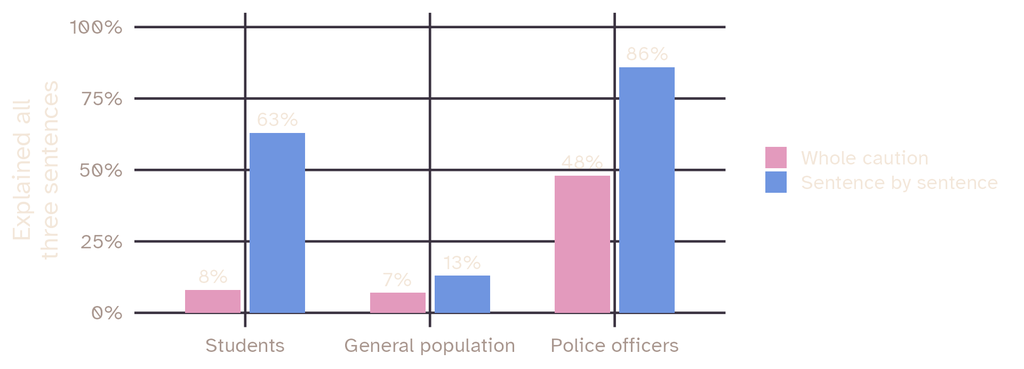

Data from Clare, Gudjonsson and Harari (1998). The caution replaced a 60-word draft that had proved too complex. The shorter version was no easier to explain.

## Miranda

In *Miranda v. Arizona* (1966), the US Supreme Court ruled that suspects in custody must be read the Miranda warnings before questioning: to remain silent, and to have a lawyer. The Court did not fix the wording.

- Rogers and colleagues (2007) collected 560 versions of the Miranda warnings used across the United States
- Measured by Flesch-Kincaid reading level, the easiest needed about second-grade reading skills. The hardest needed postgraduate education

A later survey of 945 jurisdictions found 866 versions, from 21 to 408 words long (Rogers et al., 2008).

## Why rights get lost

- Suspects hear the caution once, under stress, from the person who will question them. Saying “yes, I understand” is easier than admitting confusion
- Many suspects assume they already know their rights, and stop listening

Eastwood and Snook (2012) rewrote a Canadian caution for listeners, adding instructions, a list of the rights and explanations in other words. Listeners understood 73% of the information, against 37% for the original.

# Police interviews

`Did you know:` in an experiment in South Africa, vervet groups learned to avoid maize of one colour. When young males later moved to a group that preferred the other colour, most of them switched to the local preference.

*Source: van de Waal, Borgeaud & Whiten (2013), Science*

## From confession to information

In the 1970s and 1980s, the Court of Appeal in England and Wales found that several high-profile convictions rested on confessions that were not voluntary.

- The Police and Criminal Evidence Act 1984 (PACE) brought in rules for detention and interviews, including tape-recording
- In 1992, police training moved to investigative interviewing, which aims to gather reliable information. A confession is one possible outcome among others

## PEACE

| Stage | What happens |
| --- | --- |
| **P**lanning and preparation | What needs to be established, what evidence there is |
| **E**ngage and explain | Build rapport; explain the purpose and the rules of the interview |
| **A**ccount, clarification, challenge | The interviewee’s own account first; then questions, and inconsistencies raised |
| **C**losure | Summarise, let the interviewee correct, explain what happens next |
| **E**valuation | How the information fits the investigation, and how the interviewer did |

## The accusatorial alternative

The best-known accusatorial method is the Reid technique, widely taught in the United States. The interviewer presumes guilt, confronts the suspect, rejects denials and may minimise the offence or claim evidence that does not exist.

A meta-analysis of experiments where the truth was known compared the two styles with plain direct questioning (Meissner et al., 2014):

- Accusatorial methods raised the number of true confessions, and also the number of false ones
- Information-gathering methods kept or raised true confessions while reducing false ones

## Discussion

Accusatorial interviews produce more confessions overall, false ones included. Imagine a police chief whose force is judged on how many cases it solves.

What would persuade them to switch to PEACE? And who pays the price if they don’t?

## Suggestibility

Some people give in to questioning more than others. Gudjonsson (1984) built a test of this interrogative suggestibility.

- The interviewee hears a short story and recalls it. Then come 20 questions, 15 of them leading questions
- After the first round, the interviewer says firmly that there were several mistakes, and asks all the questions again

Yield counts how many leading questions the person accepts, and shift how many answers change after the negative feedback. Adolescents and anxious interviewees tend to score higher, and so do people with poorer memory.

## One verb

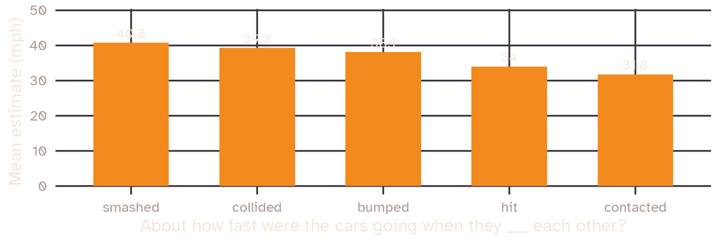

Loftus and Palmer (1974): students watched films of car crashes. A week later, 32% of those asked the “smashed” question remembered broken glass, which the film did not show, against 14% for “hit” and 12% with no speed question.

## Who writes the statement?

- Until tape-recording, a suspect’s statement was often written by an officer and signed by the suspect. In the UK, many witness statements are still written this way: the officer listens, writes, and reads back
- What ends up on paper can follow the officer’s wording more than the speaker’s

Next session we look at a case where linguists tested whose words a “verbatim” statement really contained.

# Questions in court

`Did you know:` vervet monkeys keep track of who is unreliable. After hearing one monkey’s call about a neighbouring group again and again with no neighbours in sight, they also ignored that monkey’s other calls with the same meaning.

*Source: Cheney & Seyfarth (1988), Animal Behaviour*

## Who controls the talk?

In adversarial systems such as those of the UK, the US and Australia, lawyers ask and witnesses answer.

- In cross-examination, lawyers prefer closed questions: yes/no questions, tag questions (“You were there, weren’t you?”) and statements to be confirmed
- The witness rarely tells the story in their own order or words. The lawyer’s version of events is in the question, and the witness can accept it or resist it

## Gratuitous concurrence

Many Aboriginal Australians answer “yes” to a direct question to show cooperation, or to end an uncomfortable exchange, whatever they think of its content. Researchers call this gratuitous concurrence (Liberman, 1981; Eades, 1992).

- Direct questions can be impolite in Aboriginal interaction, and a silence before answering need not mean evasion
- In court, a string of “yes” answers can look like agreement to a proposition the witness never accepted
- In 2022, the Federal Court of Australia recognised gratuitous concurrence in a civil case for the first time (*ASIC v Select AFSL*)

## The Pinkenba case

In May 1994, six Queensland police officers picked up three Aboriginal boys, aged 12, 13 and 14, in Brisbane, drove them to an industrial area at Pinkenba and left them there in the middle of the night.

- The officers were charged, and the boys were the prosecution witnesses
- In cross-examination, defence lawyers asked long series of leading questions, and the boys often answered with a minimal “yes” or with silence (Eades, 2008)

The magistrate found that the boys had agreed to go with the police, and the charges were dropped.

## Powerful and powerless speech

Studying a North Carolina courtroom, O’Barr (1982) noticed that some witnesses used a powerless style, with many hedges (“sort of”, “I think”), intensifiers (“very, very”), hesitations and polite forms. He linked it to lower social status more than to gender.

In an experiment, listeners heard the same testimony in either style (Erickson et al., 1978). Witnesses who spoke in the powerful style were rated as more credible and more attractive, and the position they supported was more often accepted.

## Instructions for the jury

At the end of a trial, the judge explains the relevant law to the jury, often reading standard pattern instructions.

- Charrow and Charrow (1979) found that jurors misunderstood much of California’s civil jury instructions, and understood significantly more after a linguistic rewrite: shorter sentences, active verbs, fewer legal terms and nominalisations
- Later studies repeated the pattern: jurors understood less than half of some instructions, and about twice as much after rewriting (Steele & Thornburg, 1988)

# Interpreters

`Did you know:` green monkeys in Senegal, close relatives of vervets, had no eagle alarm. When researchers flew a drone over them, they gave a new alarm call that sounded almost the same as the eagle alarm of East African vervets, although the two species split about 3.5 million years ago.

*Source: Wegdell, Hammerschmidt & Fischer (2019), Nature Ecology & Evolution*

## The interpreter’s words are the evidence

When a witness speaks through an interpreter, the judge and jury hear only the interpretation, and that rendition becomes the testimony they assess (Hale, 2004).

- Berk-Seligson (1990/2017) recorded more than 100 hours of Spanish–English proceedings in US courts
- Interpreters often lengthened answers, added or dropped politeness, changed the register, and turned active sentences into passives or the reverse, usually without noticing

## Does it change verdicts?

In mock juror experiments, Berk-Seligson played the same testimony with different interpretations.

- A witness interpreted as polite was rated more convincing, more competent and more trustworthy than the same witness interpreted without politeness
- Interpreters also softened or sharpened lawyers’ leading questions, which changed how much pressure the witness felt (Berk-Seligson, 1999)

## Interpreting in police interviews

Most of the problems from the courtroom appear in police interviews too, often with less control:

- Interpreters may be untrained, or chosen ad hoc from police staff or the community
- The caution and the suspect’s rights must be interpreted as well, and legal terms may have no close equivalent
- Recordings let analysts check the interpretation later, if both languages were recorded

## Discussion

- Should suspects have to explain the caution back in their own words before an interview can go ahead?
- A witness says “yes” to every question in cross-examination. How could a court tell agreement from gratuitous concurrence?

## Activity

For the next session:

1. Write a plain-language version of the caution, with the same three pieces of information
2. Read the original caution aloud to two people who have not studied it, and ask them to explain each sentence in their own words
3. Do the same with your version for two other people
4. Score each explanation as complete, partial or wrong, and bring the results to class

## Summary

- Police cautions and Miranda warnings are often misunderstood, even by people who say they understand them
- Information-gathering interviews such as PEACE keep true confessions and reduce false ones; accusatorial methods raise both
- Leading questions and negative feedback change what witnesses say, and some people are more suggestible than others
- Courtroom questions control the story, and cultural habits such as gratuitous concurrence can be read as agreement
- Interpreters shape the testimony that judges and juries hear

## References

- Berk-Seligson, S. (1999). The impact of court interpreting on the coerciveness of leading questions. *International Journal of Speech, Language and the Law*, 6(1), 30–56.
- Berk-Seligson, S. (2017). *The bilingual courtroom: Court interpreters in the judicial process* (2nd ed.). University of Chicago Press. (1st ed. 1990)
- Charrow, R. P., & Charrow, V. R. (1979). Making legal language understandable: A psycholinguistic study of jury instructions. *Columbia Law Review*, 79(7), 1306–1374.
- Clare, I. C. H., Gudjonsson, G. H., & Harari, P. M. (1998). Understanding of the current police caution (England and Wales). *Journal of Community & Applied Social Psychology*, 8(5), 323–329.
- Eades, D. (1992). *Aboriginal English and the law*. Queensland Law Society.
- Eastwood, J., & Snook, B. (2012). The effect of listenability factors on the comprehension of police cautions. *Law and Human Behavior*, 36(3).

## References

- Eades, D. (2008). *Courtroom talk and neocolonial control*. Mouton de Gruyter.
- Erickson, B., Lind, E. A., Johnson, B. C., & O’Barr, W. M. (1978). Speech style and impression formation in a court setting: The effects of “powerful” and “powerless” speech. *Journal of Experimental Social Psychology*, 14(3), 266–279.
- Fenner, S., Gudjonsson, G. H., & Clare, I. C. H. (2002). Understanding of the current police caution (England and Wales) among suspects in police detention. *Journal of Community & Applied Social Psychology*, 12(2), 83–93.
- Gudjonsson, G. H. (1984). A new scale of interrogative suggestibility. *Personality and Individual Differences*, 5(3), 303–314.
- Hale, S. (2004). *The discourse of court interpreting*. John Benjamins.
- Leemann, A., Perkins, R., Sullivan Buker, G., & Foulkes, P. (2024). *An Introduction to Forensic Phonetics and Forensic Linguistics*. Routledge. Chapter 10.
- Liberman, K. (1981). Understanding Aborigines in Australian courts of law. *Human Organization*, 40(3), 247–255.

## References

- Loftus, E. F., & Palmer, J. C. (1974). Reconstruction of automobile destruction: An example of the interaction between language and memory. *Journal of Verbal Learning and Verbal Behavior*, 13(5), 585–589.
- Meissner, C. A., Redlich, A. D., Michael, S. W., Evans, J. R., Camilletti, C. R., Bhatt, S., & Brandon, S. (2014). Accusatorial and information-gathering interrogation methods and their effects on true and false confessions: A meta-analytic review. *Journal of Experimental Criminology*, 10(4), 459–486.
- O’Barr, W. M. (1982). *Linguistic evidence: Language, power, and strategy in the courtroom*. Academic Press.
- Rogers, R., Harrison, K. S., Shuman, D. W., Sewell, K. W., & Hazelwood, L. L. (2007). An analysis of Miranda warnings and waivers: Comprehension and coverage. *Law and Human Behavior*, 31(2), 177–192.
- Rogers, R., Hazelwood, L. L., Sewell, K. W., Harrison, K. S., & Shuman, D. W. (2008). The language of Miranda warnings in American jurisdictions: A replication and vocabulary analysis. *Law and Human Behavior*, 32(2), 124–136.
- Steele, W. W., & Thornburg, E. G. (1988). Jury instructions: A persistent failure to communicate. *North Carolina Law Review*, 67(1), 77–119.

## Sources of the animal facts

- Cheney, D. L., & Seyfarth, R. M. (1988). Assessment of meaning and the detection of unreliable signals by vervet monkeys. *Animal Behaviour*, 36(2), 477–486. https://doi.org/10.1016/S0003-3472(88)80018-6
- Seyfarth, R. M., Cheney, D. L., & Marler, P. (1980). Monkey responses to three different alarm calls: Evidence of predator classification and semantic communication. *Science*, 210(4471), 801–803. https://doi.org/10.1126/science.7433999
- van de Waal, E., Borgeaud, C., & Whiten, A. (2013). Potent social learning and conformity shape a wild primate’s foraging decisions. *Science*, 340(6131), 483–485. https://doi.org/10.1126/science.1232769
- Wegdell, F., Hammerschmidt, K., & Fischer, J. (2019). Conserved alarm calls but rapid auditory learning in monkey responses to novel flying objects. *Nature Ecology & Evolution*, 3(7), 1039–1042. https://doi.org/10.1038/s41559-019-0903-5

## Slides and code

[figure not shown]

These slides

mcanzi.de/ws27_fss/08_judicial_process.html

Code and all sessions

github.com/mcanzi/ws27_fss